# Final Quiz Business Statistics

```r
options(warn=0)
library(readxl)
library(MASS)
library(car)
library(corrplot)
library(psych)
library(ggplot2)
library(tidyr)
```

# Data Cleaning

## Data Overview

```r
mydata <- housedata_for_final_2018_1_
describe(mydata)
```

|  | vars | n | mean | sd | median | trimmed | mad | min | max | range | skew | kurtosis | se |
| --- | --- | --- | --- | --- | --- | --- | --- | --- | --- | --- | --- | --- | --- |
| s_p | 1 | 950 | 79037.11 | 29169.78 | 70360.00 | 74918.59 | 20115.92 | 29864.00 | 222680.00 | 192816.00 | 1.71 | 4.05 | 946.39 |
| inv | 2 | 950 | 140.82 | 53.28 | 135.00 | 133.24 | 45.96 | 61.00 | 322.00 | 261.00 | 1.24 | 1.20 | 1.73 |
| bath | 3 | 950 | 1.95 | 0.87 | 2.00 | 1.89 | 0.74 | 1.00 | 20.00 | 19.00 | 9.38 | 188.84 | 0.03 |
| ltsz | 4 | 950 | 0.33 | 0.43 | 0.22 | 0.24 | 0.07 | 0.02 | 4.13 | 4.12 | 4.90 | 28.72 | 0.01 |
| hssz | 5 | 950 | 1055.49 | 296.61 | 1014.00 | 1034.73 | 222.39 | 216.00 | 3080.00 | 2864.00 | 1.36 | 5.36 | 9.62 |
| bsemt | 6 | 950 | 0.94 | 0.24 | 1.00 | 1.00 | 0.00 | 0.00 | 1.00 | 1.00 | -3.59 | 10.87 | 0.01 |
| a_c | 7 | 950 | 0.81 | 0.39 | 1.00 | 0.89 | 0.00 | 0.00 | 1.00 | 1.00 | -1.61 | 0.59 | 0.01 |
| f_place | 8 | 950 | 0.60 | 0.49 | 1.00 | 0.62 | 0.00 | 0.00 | 1.00 | 1.00 | -0.39 | -1.85 | 0.02 |
| garsz_a | 9 | 950 | 0.96 | 0.20 | 1.00 | 1.00 | 0.00 | 0.00 | 2.00 | 2.00 | -4.35 | 19.57 | 0.01 |
| dw | 10 | 950 | 0.81 | 0.40 | 1.00 | 0.88 | 0.00 | 0.00 | 1.00 | 1.00 | -1.55 | 0.40 | 0.01 |

[output cut: 5 more lines]

```r
attach(mydata)
```

## Odd Values

There were several other places in the dataset that gave me pause and that I went onto investigate further. In this section, I look into instances where attributes didn’t make sense. ###Bath

```r
highbathrooms <- mydata[mydata$bath>5,]
mydata$bath[bath == 20] <- 2
highbathrooms
```

| s_p | inv | bath | ltsz | hssz | bsemt | a_c | f_place | garsz_a | dw | dr | fr | age5 | stl10 | bdrms |
| --- | --- | --- | --- | --- | --- | --- | --- | --- | --- | --- | --- | --- | --- | --- |
| 86398 | 100 | 20 | 0.3305785 | 1400 | 1 | 1 | 1 | 1 | 1 | 1 | 0 | 1 | 1 | 3 |

Given the size of the lot, livingspace and number of bedrooms, I believe Bath = 20 is an error and that the true number of bathrooms is 2.

### Bedrooms

```r
lowbedrooms <- mydata[mydata$bdrms <1,]
lowbedrooms
```

| s_p | inv | bath | ltsz | hssz | bsemt | a_c | f_place | garsz_a | dw | dr | fr | age5 | stl10 | bdrms |
| --- | --- | --- | --- | --- | --- | --- | --- | --- | --- | --- | --- | --- | --- | --- |
| 60249 | 65 | 1 | 0.1515152 | 988 | 1 | 1 | 0 | 1 | 0 | 0 | 0 | 1 | 1 | -4 |

```r
mydata$bdrms[bdrms == -4] <- 4
attach(mydata)
```

One instance has a value of -4 for bedrooms. Given -4 bedrooms is not possible, this data is a typo. Most likely, the true number of bedrooms is 4. However, given the area is small and the property only has one bathroom, I believe it would be a good idea to investigate this further in the future if given more time.

### Garage

```r
mydata[garsz_a == 2,]
```

| s_p | inv | bath | ltsz | hssz | bsemt | a_c | f_place | garsz_a | dw | dr | fr | age5 | stl10 | bdrms |
| --- | --- | --- | --- | --- | --- | --- | --- | --- | --- | --- | --- | --- | --- | --- |
| 51826 | 204 | 1.5 | 0.1565657 | 912 | 1 | 1 | 0 | 2 | 1 | 0 | 1 | 0 | 1 | 4 |

```r
mydata$garsz_a[garsz_a == 2] <- 1
attach(mydata)
```

garsz_a is a binary variable which should have a value of 0 or 1 to indicate the presence of a garage at the home. One home had a value of 2. This most likely a typo an the real value should be 1.

### House Size

```r
lowhssz <- mydata[mydata$hssz <500,]
lowhssz
```

| s_p | inv | bath | ltsz | hssz | bsemt | a_c | f_place | garsz_a | dw | dr | fr | age5 | stl10 | bdrms |
| --- | --- | --- | --- | --- | --- | --- | --- | --- | --- | --- | --- | --- | --- | --- |
| 46188 | 201 | 1.5 | 0.10743801 | 480 | 0 | 1 | 0 | 1 | 1 | 1 | 0 | 0 | 0 | 2 |
| 32666 | 128 | 1.0 | 0.04591368 | 480 | 1 | 0 | 0 | 1 | 0 | 1 | 0 | 0 | 1 | 1 |
| 44966 | 155 | 1.5 | 0.11019284 | 224 | 1 | 0 | 0 | 0 | 0 | 1 | 0 | 0 | 0 | 3 |
| 53323 | 99 | 1.0 | 0.15702480 | 288 | 1 | 1 | 1 | 1 | 1 | 0 | 1 | 0 | 1 | 3 |
| 58000 | 116 | 2.0 | 0.12913223 | 432 | 1 | 1 | 1 | 1 | 1 | 1 | 1 | 1 | 0 | 3 |
| 94513 | 264 | 2.5 | 0.24173553 | 495 | 1 | 1 | 1 | 1 | 1 | 1 | 1 | 1 | 0 | 3 |
| 58772 | 309 | 2.0 | 0.22956841 | 494 | 1 | 1 | 1 | 1 | 1 | 1 | 1 | 0 | 0 | 3 |
| 40209 | 162 | 1.5 | 0.09508724 | 448 | 0 | 1 | 0 | 1 | 1 | 1 | 0 | 1 | 0 | 2 |
| 46620 | 134 | 1.5 | 0.10743801 | 480 | 0 | 1 | 0 | 1 | 1 | 1 | 0 | 0 | 0 | 2 |
| 92237 | 136 | 1.5 | 0.27548209 | 216 | 1 | 1 | 1 | 1 | 1 | 1 | 1 | 0 | 0 | 4 |

[output cut: 5 more lines]

```r
attach(mydata)
```

Looking again at the minimums, I see one house has an hssz of 216 square feet. this is small, particularly when I noticed that that property has 4 bedrooms. If I had more time, I would investigate this further to see if this was a true value. ###Lot Size

```r
lowltsz <- mydata[ltsz<.03,]
mydata$ltszratio <- mydata$hssz/(mydata$ltsz*43560)
lowltsz <- mydata[mydata$ltszratio > 1 & mydata$stl10 == 0 , ]
lowltsz
```

| s_p | inv | bath | ltsz | hssz | bsemt | a_c | f_place | garsz_a | dw | dr | fr | age5 | stl10 | bdrms | ltszratio |
| --- | --- | --- | --- | --- | --- | --- | --- | --- | --- | --- | --- | --- | --- | --- | --- |
| 55512 | 114 | 1.5 | 0.01561065 | 816 | 1 | 0 | 0 | 1 | 0 | 1 | 1 | 0 | 0 | 3 | 1.2 |

There should not be a case when the ltsz is smaller than the house size if the house is only 1 story. However in this case, it is possible that the additional square footage is coming from the basement so I should leave the data.

## Histograms

Now that the data has been cleaned, let’s take a look at the histograms.

First, I looked at the target variable, Sales Price.

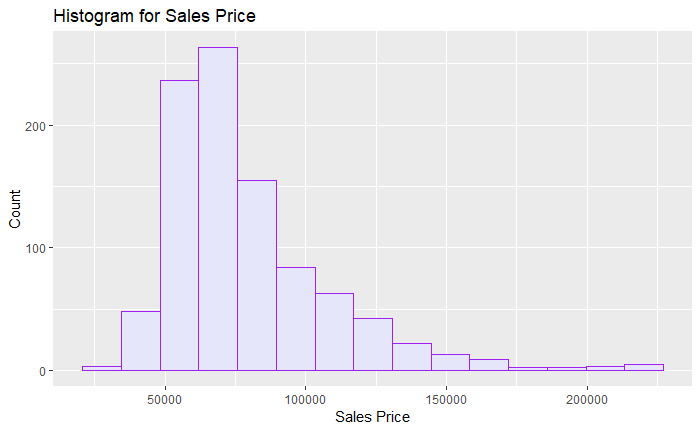

```r
qplot(s_p,
      geom="histogram",
      bins = 15,
      main = "Histogram for Sales Price",
      xlab = "Sales Price",
      ylab = "Count",
      fill=I("lavender"),
      col=I("purple"))
```

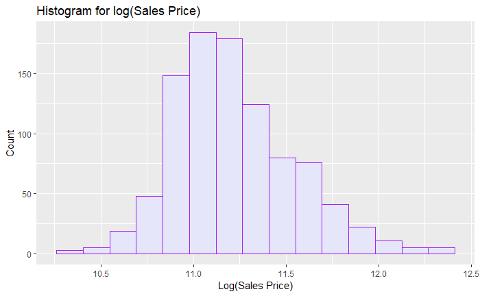

```r
qplot(log(s_p),
      geom="histogram",
      bins = 15,
      main = "Histogram for log(Sales Price)",
      xlab = "Log(Sales Price)",
      ylab = "Count",
      fill=I("lavender"),
      col=I("purple"))
```

```r
NA
```

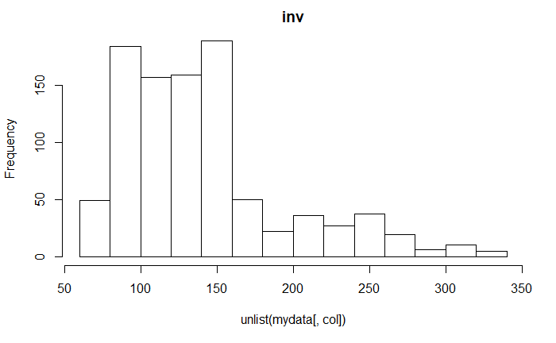

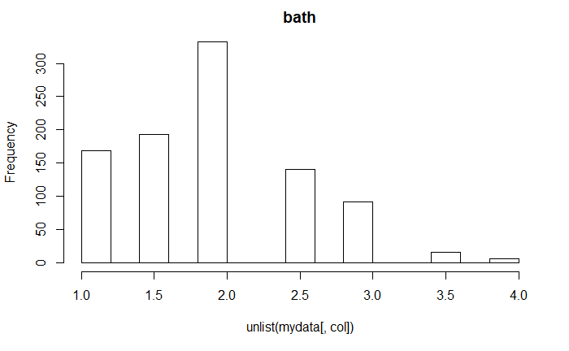

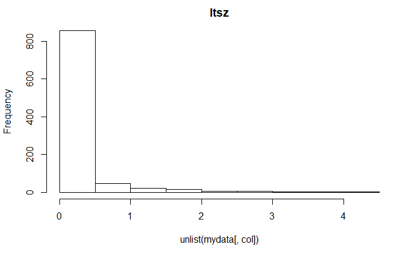

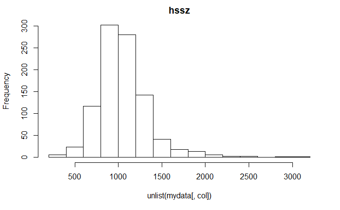

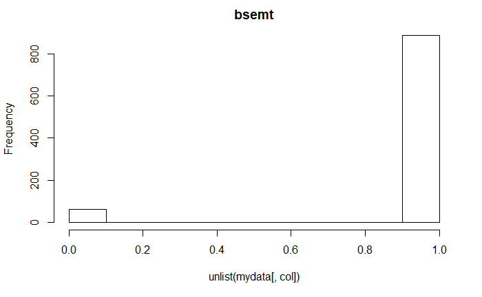

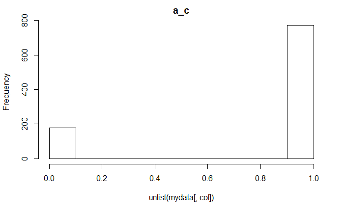

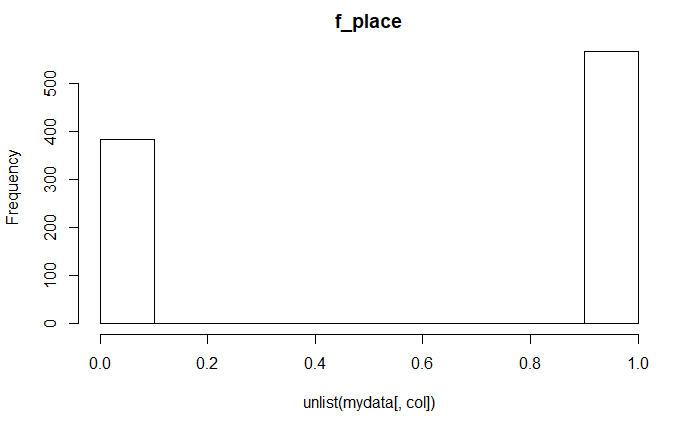

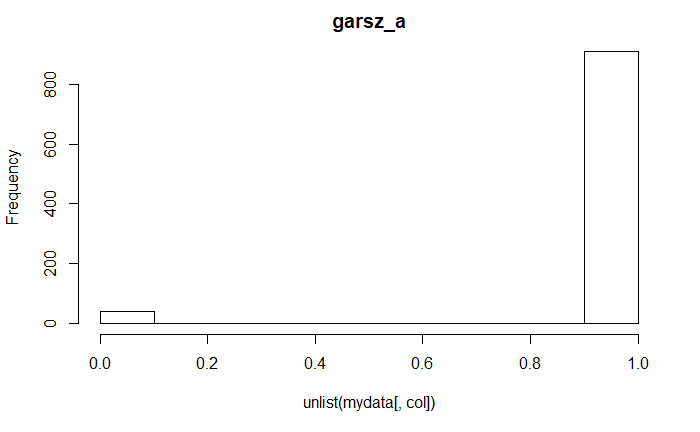

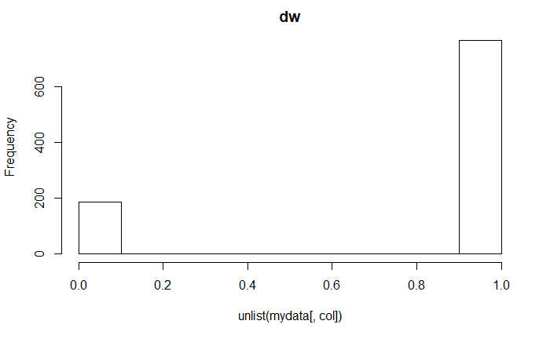

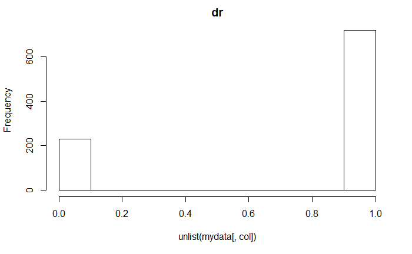

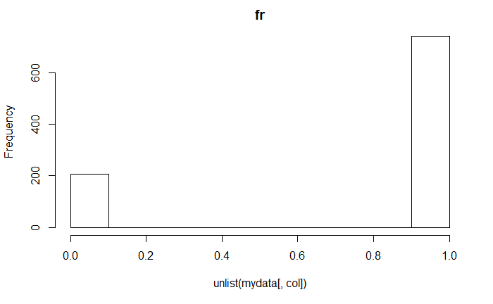

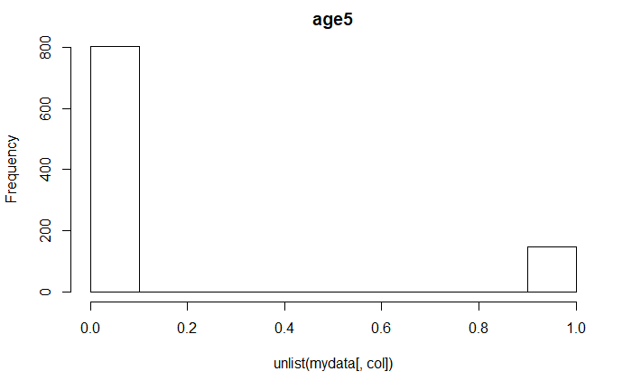

[3 more figures not shown]

```r
for (col in 2:ncol(mydata)){
  hist(unlist(mydata[,col]), main = names(mydata[col]))
}
```

## Correlations

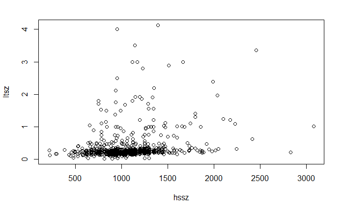

```r
plot(hssz, ltsz)
```

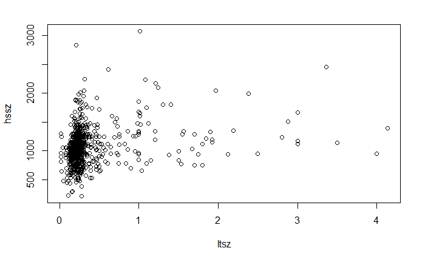

```r
plot(ltsz, hssz)
```

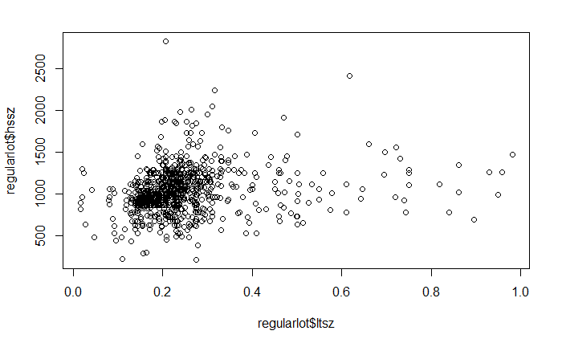

```r
regularlot <- mydata[ltsz < 1, ]
plot(regularlot$ltsz, regularlot$hssz)
```

```r
cor(mydata)
```

```
                s_p          inv        bath        ltsz       hssz        bsemt         a_c     f_place     garsz_a          dw          dr          fr         age5       stl10        bdrms
s_p      1.00000000  0.075265157  0.62332262  0.48471784 0.40302121  0.160443217  0.26820048  0.48467559  0.16688618  0.34707740  0.33738495  0.28017849  0.265941586 -0.22700986  0.440233180
inv      0.07526516  1.000000000  0.09215439  0.10366549 0.09023423 -0.050458023  0.11441777  0.11836174  0.11369106  0.23496523  0.08934581  0.10430371  0.004636197 -0.01306630  0.017292918
bath     0.62332262  0.092154391  1.00000000  0.28897026 0.34308559  0.135208321  0.30013167  0.44653934  0.18068398  0.39017577  0.32189773  0.40840824  0.134066391 -0.20884541  0.526301002
ltsz     0.48471784  0.103665486  0.28897026  1.00000000 0.26136144  0.078818751  0.08429919  0.22683247  0.07755884  0.14443338  0.15648776  0.12591320  0.074357052 -0.05363533  0.176506511
hssz     0.40302121  0.090234233  0.34308559  0.26136144 1.00000000  0.017621117  0.18327055  0.25517864  0.14443959  0.26164452  0.20381042  0.16660137  0.168929286  0.08870037  0.209309517
bsemt    0.16044322 -0.050458023  0.13520832  0.07881875 0.01762112  1.000000000  0.05358194  0.05125987  0.03533326  0.06985198  0.05601828  0.18791629  0.002652432 -0.11768682  0.083447494
a_c      0.26820048  0.114417775  0.30013167  0.08429919 0.18327055  0.053581944  1.00000000  0.30114480  0.26102322  0.40853420  0.18540800  0.31063105  0.181424493 -0.14163114  0.172961782
f_place  0.48467559  0.118361737  0.44653934  0.22683247 0.25517864  0.051259874  0.30114480  1.00000000  0.14980612  0.37369511  0.28434982  0.33032655  0.165777565 -0.22167356  0.259494154
garsz_a  0.16688618  0.113691060  0.18068398  0.07755884 0.14443959  0.035333263  0.26102322  0.14980612  1.00000000  0.26696392  0.11102001  0.15250442  0.057195408 -0.05379144  0.093643716
dw       0.34707740  0.234965231  0.39017577  0.14443338 0.26164452  0.069851977  0.40853420  0.37369511  0.26696392  1.00000000  0.30294577  0.32847429  0.171925207 -0.17520240  0.256945329
dr       0.33738495  0.089345811  0.32189773  0.15648776 0.20381042  0.056018276  0.18540800  0.28434982  0.11102001  0.30294577  1.00000000  0.14368573  0.042265191 -0.24903742  0.163917357
fr       0.28017849  0.104303707  0.40840824  0.12591320 0.16660137  0.187916294  0.31063105  0.33032655  0.15250442  0.32847429  0.14368573  1.00000000 -0.015465413 -0.19379137  0.319568393
age5     0.26594159  0.004636197  0.13406639  0.07435705 0.16892929  0.002652432  0.18142449  0.16577757  0.05719541  0.17192521  0.04226519 -0.01546541  1.000000000 -0.07106999 -0.006445345
stl10   -0.22700986 -0.013066303 -0.20884541 -0.05363533 0.08870037 -0.117686819 -0.14163114 -0.22167356 -0.05379144 -0.17520240 -0.24903742 -0.19379137 -0.071069993  1.00000000 -0.205232113
bdrms    0.44023318  0.017292918  0.52630100  0.17650651 0.20930952  0.083447494  0.17296178  0.25949415  0.09364372  0.25694533  0.16391736  0.31956839 -0.006445345 -0.20523211  1.000000000
```

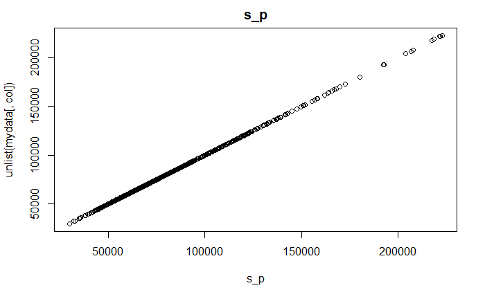

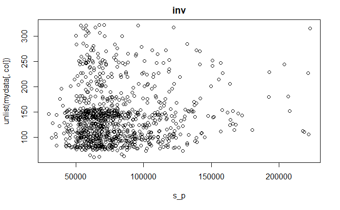

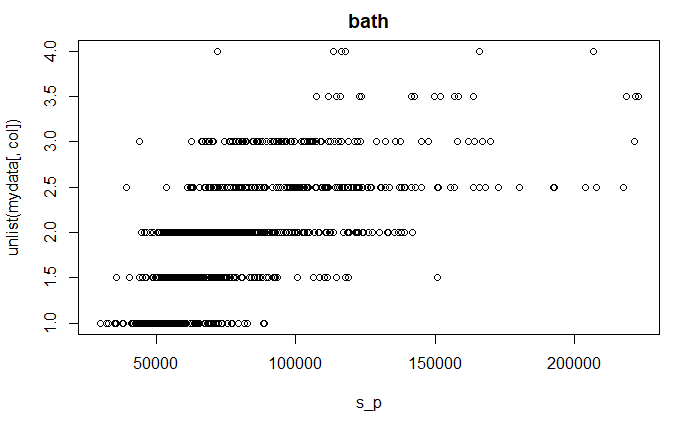

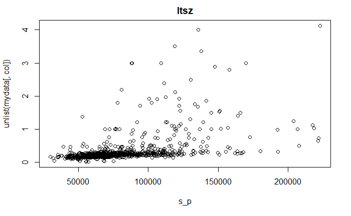

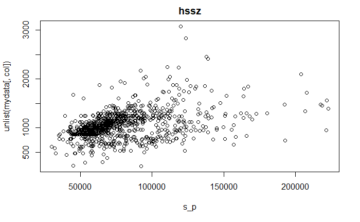

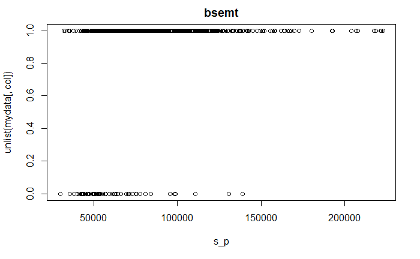

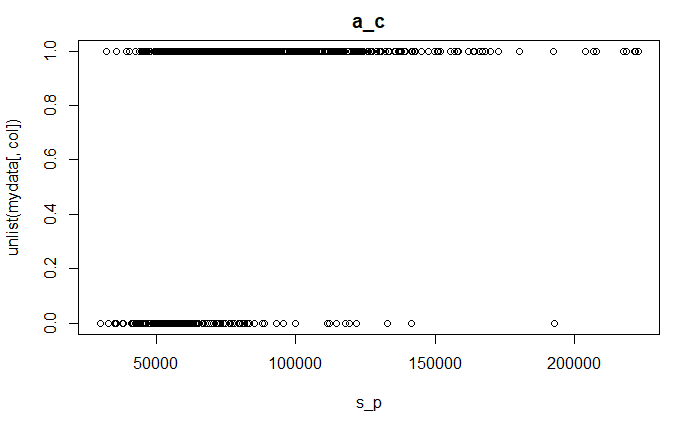

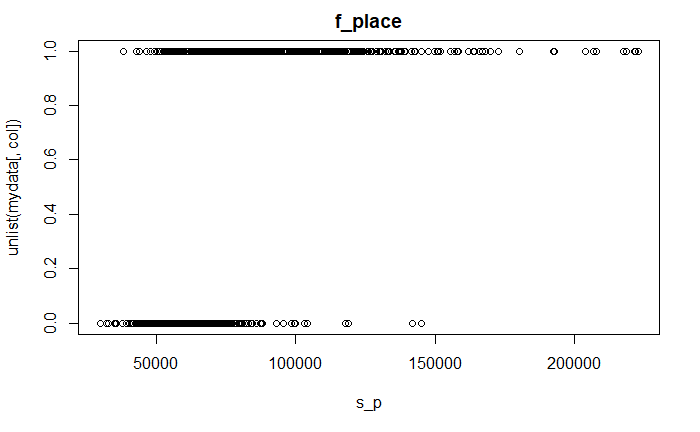

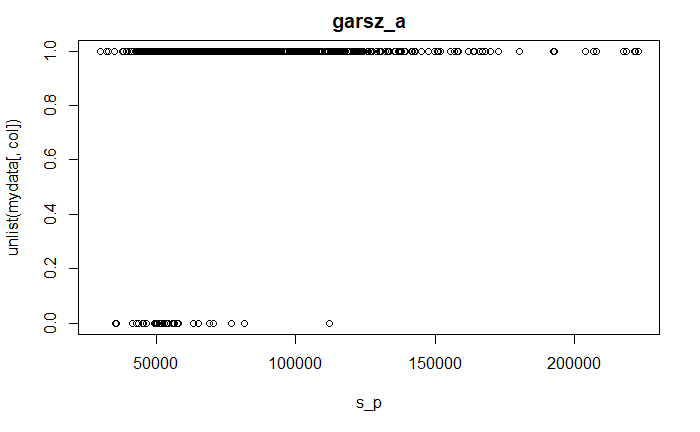

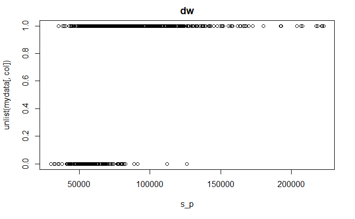

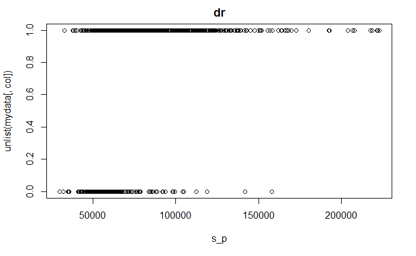

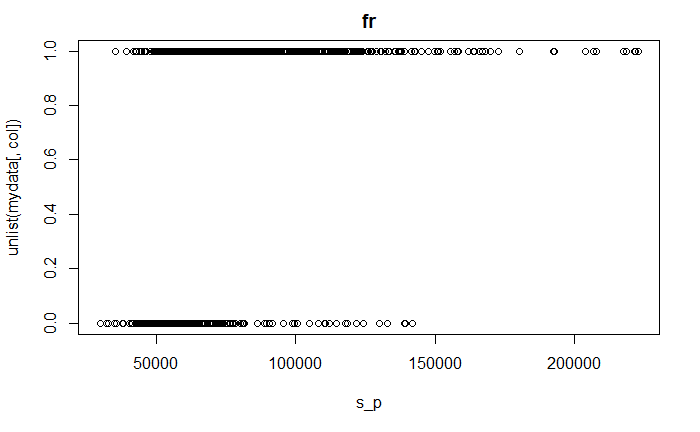

[4 more figures not shown]

```r
for (col in 1:ncol(mydata)){
  plot(s_p,unlist(mydata[,col]),main = names(mydata[col]) )
}
```

Now the data needs to be split into training and test sets before the model can be run

```r
set.seed(12345)
mydata <- mydata[, 1:15]
train.num<-sample(1:dim(mydata)[1],round(nrow(mydata)*0.75))
mydata.train<-mydata[train.num,]
mydata.test<-mydata[-train.num,]
```

```r
everythingmodel<- lm(s_p ~ ., data = mydata.train)
summary(everythingmodel)
```

```
Call:
lm(formula = s_p ~ ., data = mydata.train)

Residuals:
   Min     1Q Median     3Q    Max
-71658 -10574  -1697   7753 104743

Coefficients:
             Estimate Std. Error t value Pr(>|t|)
(Intercept) -4294.714   5895.325  -0.728  0.46656
inv           -15.167     13.632  -1.113  0.26626
bath        12558.253   1480.839   8.480  < 2e-16 ***
ltsz        20770.554   1769.357  11.739  < 2e-16 ***
hssz           11.208      2.676   4.188 3.17e-05 ***
bsemt        8874.439   2849.393   3.115  0.00192 **
a_c           545.634   2052.230   0.266  0.79042
f_place      9681.278   1701.132   5.691 1.86e-08 ***
garsz_a      4589.219   3717.939   1.234  0.21749
dw           1751.023   2183.632   0.802  0.42289
dr           4907.176   1800.735   2.725  0.00659 **
fr          -2493.871   1982.630  -1.258  0.20886
age5        10258.948   2043.380   5.021 6.55e-07 ***
stl10       -3450.259   1546.229  -2.231  0.02597 *
bdrms        6085.729   1236.049   4.924 1.06e-06 ***
---
Signif. codes:  0 *** 0.001 ** 0.01 * 0.05 . 0.1   1

Residual standard error: 18540 on 697 degrees of freedom
Multiple R-squared:  0.5979,    Adjusted R-squared:  0.5898
F-statistic: 74.02 on 14 and 697 DF,  p-value: < 2.2e-16
```

This is what it looks like if I just throw in every attribute into the model. I can use this model in the step function to use backward selection to choose the best attributes by taking out variables one at a time and examine the effect on the model. It should be noted that while this is effective, it is also necessarily to examine the attributes, their correlations and residuals by hand to look for various ways in which the attributes can be transformed to create a more successful model.

From here, let’s do some backwards selection.

```r
print("backward")
```

```
[1] "backward"
```

```r
step(everythingmodel,direction = "backward",trace = 0)
```

```
Call:
lm(formula = s_p ~ bath + ltsz + hssz + bsemt + f_place + dr +
    age5 + stl10 + bdrms, data = mydata.train)

Coefficients:
(Intercept)         bath         ltsz         hssz        bsemt      f_place           dr         age5        stl10        bdrms
   -1966.15     12424.66     20629.49        11.49      8556.73      9600.35      5355.99     10903.64     -3424.80      6015.30
```

```r
print("forward")
```

```
[1] "forward"
```

```r
step(everythingmodel,direction = "forward",trace = 0)
```

```
Call:
lm(formula = s_p ~ inv + bath + ltsz + hssz + bsemt + a_c + f_place +
    garsz_a + dw + dr + fr + age5 + stl10 + bdrms, data = mydata.train)

Coefficients:
(Intercept)          inv         bath         ltsz         hssz        bsemt          a_c      f_place      garsz_a           dw           dr           fr         age5
   -4294.71       -15.17     12558.25     20770.55        11.21      8874.44       545.63      9681.28      4589.22      1751.02      4907.18     -2493.87     10258.95
      stl10        bdrms
   -3450.26      6085.73
```

This shows us that our most significant variables are the following : bath, ltsz, hssz, bsemt, f_place, dr, age5, stl10, bdrms But if there’s multicolinearity, this could have negative affects on the model. I can check for multicolinearity using the vif function (completed in a few more steps). #Model Building

## Model1

```r
model1 <-lm(s_p ~ factor(bath) + ltsz + f_place + age5 + stl10 +bsemt + dr + factor(bdrms) + stl10 + hssz, data = mydata.train)
summary(model1)
```

```
Call:
lm(formula = s_p ~ factor(bath) + ltsz + f_place + age5 + stl10 +
    bsemt + dr + factor(bdrms) + stl10 + hssz, data = mydata.train)

Residuals:
   Min     1Q Median     3Q    Max
-63167  -9717  -1346   7988  96090

Coefficients:
                 Estimate Std. Error t value Pr(>|t|)
(Intercept)     18725.580   9520.525   1.967 0.049597 *
factor(bath)1.5   650.578   2317.827   0.281 0.779036
factor(bath)2    5074.681   2195.380   2.312 0.021096 *
factor(bath)2.5 21207.526   2808.816   7.550 1.37e-13 ***
factor(bath)3   12226.631   3234.897   3.780 0.000171 ***
factor(bath)3.5 56816.831   5842.068   9.725  < 2e-16 ***
factor(bath)4   40358.344   9786.335   4.124 4.18e-05 ***
ltsz            19597.193   1682.802  11.646  < 2e-16 ***
f_place          9668.830   1595.295   6.061 2.22e-09 ***
age5            11224.259   1914.468   5.863 7.04e-09 ***
stl10           -2036.133   1496.013  -1.361 0.173944
bsemt           10258.931   2692.022   3.811 0.000151 ***
dr               5797.230   1698.605   3.413 0.000680 ***
factor(bdrms)2   5403.062   9307.173   0.581 0.561748
factor(bdrms)3  12037.388   9000.958   1.337 0.181549
factor(bdrms)4  20242.653   9169.711   2.208 0.027602 *
factor(bdrms)5  22078.396   9621.105   2.295 0.022043 *
factor(bdrms)6  30452.956  16193.937   1.881 0.060457 .
hssz               10.578      2.551   4.147 3.78e-05 ***
---
Signif. codes:  0 *** 0.001 ** 0.01 * 0.05 . 0.1   1

Residual standard error: 17600 on 693 degrees of freedom
Multiple R-squared:  0.6394,    Adjusted R-squared:   0.63
F-statistic: 68.27 on 18 and 693 DF,  p-value: < 2.2e-16
```

Examining this output, I see all of the attributes are significant accept for stl10 and some of the factored attributes. If given more time, I could turn the factored attributes into n-1 variables and use them, but in this case, they probably aren’t doing much harm to the model. Ultimately, I removed stl10 and kept the factored variables as they are for model2.

### Residuals

Next, I examin the residuals of model 1 to see if any patterns emerge that could be useful in the next model.

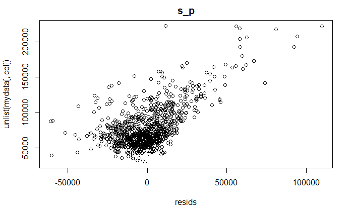

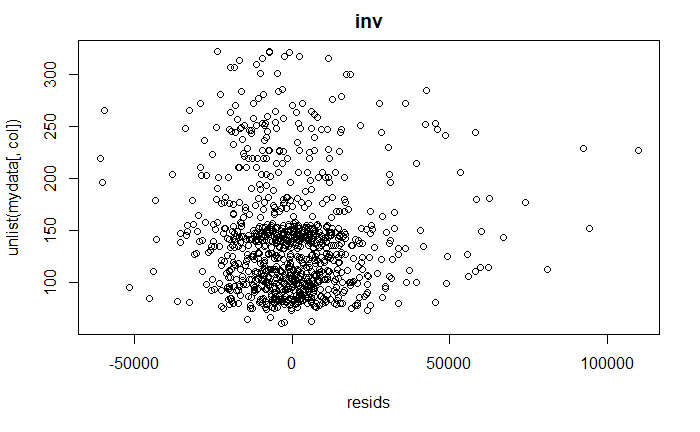

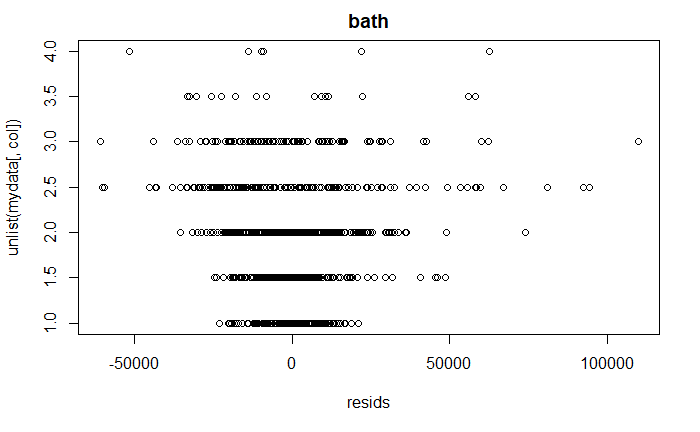

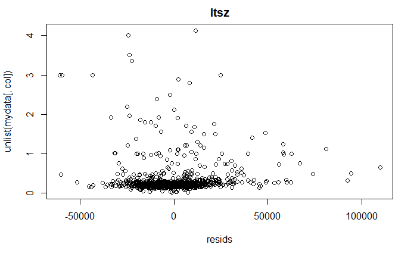

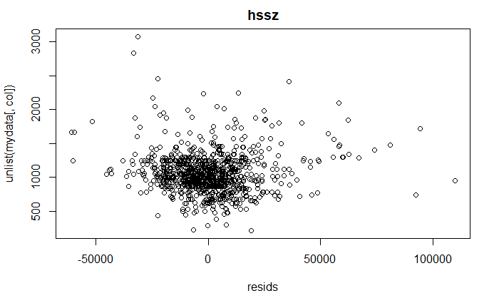

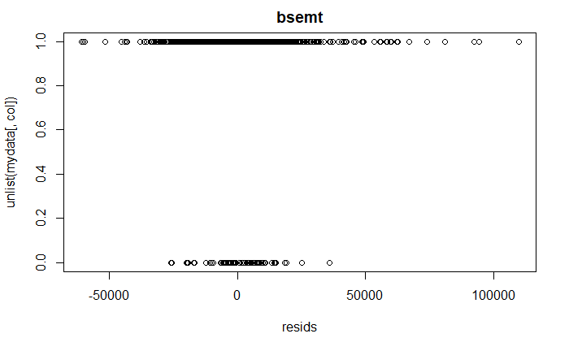

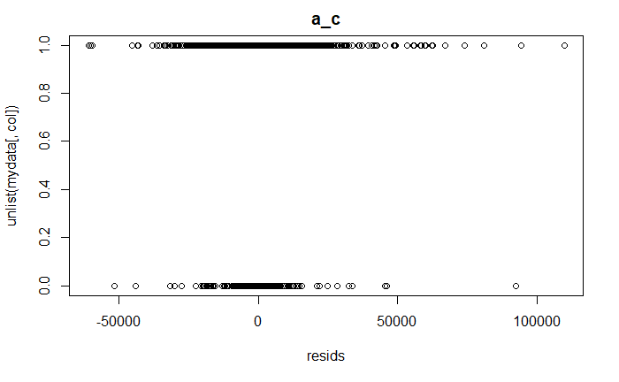

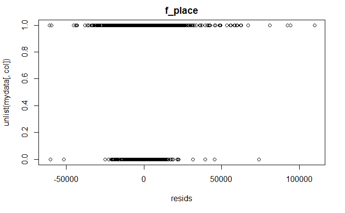

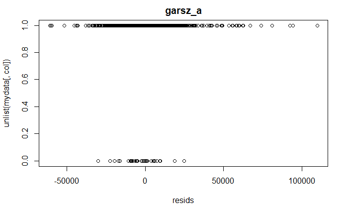

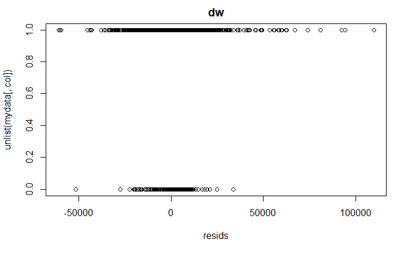

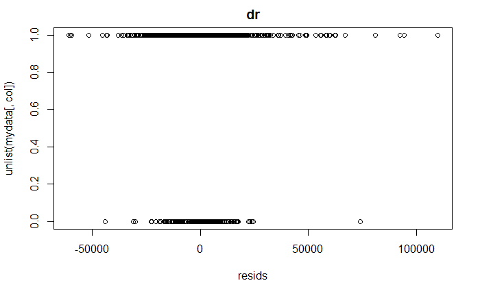

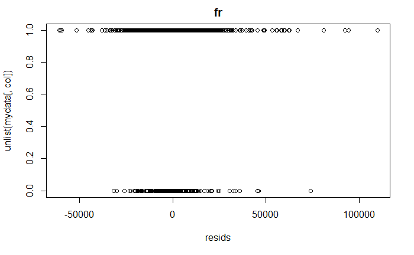

[3 more figures not shown]

```r
attach(mydata)
mydataresids <- mydata.train
mydataresids$resids <- resid(model1)
attach(mydata)
for (col in 1:ncol(mydata)){
  plot(resids,unlist(mydata[,col]),main = names(mydata[col]) )
}
```

Looking at these residual graphs, I didn’t see any clear patterns that I could use to combine variables, but I did consistantly an increase in variance that correlated with an increase in y, indicating a multiplicative affect. Later, I would try to rectify this through power transformations.

```r
vif(model1)
```

```
                  GVIF Df GVIF^(1/(2*Df))
factor(bath)  2.553075  6        1.081240
ltsz          1.154601  1        1.074524
f_place       1.414613  1        1.189375
age5          1.091851  1        1.044917
stl10         1.282968  1        1.132682
bsemt         1.046863  1        1.023163
dr            1.242994  1        1.114897
factor(bdrms) 1.889251  5        1.065685
hssz          1.319800  1        1.148826
```

None of these look too inflated, so they can stay in the model. ##model2

When I examine the residuals above, it was clear that there are still multiplicative effects that I don’t understand. This can be seen by the fact that the variance is increasing as y increases. To rectify this, I need to do some power transformations

## Power Transformations on Model2

```r
powerTransform(cbind(mydata.train$s_p, mydata.train$ltsz,mydata.train$hssz)~1)
```

```
Estimated transformation parameters
        Y1         Y2         Y3
-0.4653418 -0.2389551  0.3963689
```

This output tells up that the optimal transformation for s_p would be 1/sqrt(s_p) for ltsz, 1/log(ltsz), for hssz we’d try sqrt

```r
model2<- lm(log10(s_p) ~ factor(bath) + ltsz + f_place + age5 + dr + factor(bdrms) + hssz + bsemt, data = mydata.train)
summary(model2)
```

```
Call:
lm(formula = log10(s_p) ~ factor(bath) + ltsz + f_place + age5 +
    dr + factor(bdrms) + hssz + bsemt, data = mydata.train)

Residuals:
     Min       1Q   Median       3Q      Max
-0.36538 -0.05211 -0.00557  0.05051  0.33298

Coefficients:
                 Estimate Std. Error t value Pr(>|t|)
(Intercept)     4.456e+00  4.378e-02 101.781  < 2e-16 ***
factor(bath)1.5 1.442e-02  1.068e-02   1.351 0.177106
factor(bath)2   4.364e-02  1.020e-02   4.278 2.15e-05 ***
factor(bath)2.5 1.139e-01  1.301e-02   8.755  < 2e-16 ***
factor(bath)3   7.634e-02  1.504e-02   5.075 4.97e-07 ***
factor(bath)3.5 2.224e-01  2.702e-02   8.233 9.09e-16 ***
factor(bath)4   1.672e-01  4.529e-02   3.692 0.000240 ***
ltsz            7.718e-02  7.825e-03   9.863  < 2e-16 ***
f_place         6.102e-02  7.326e-03   8.329 4.35e-16 ***
age5            4.677e-02  8.874e-03   5.271 1.82e-07 ***
dr              3.955e-02  7.752e-03   5.101 4.36e-07 ***
factor(bdrms)2  8.287e-02  4.324e-02   1.917 0.055680 .
factor(bdrms)3  1.314e-01  4.177e-02   3.145 0.001733 **
factor(bdrms)4  1.713e-01  4.246e-02   4.034 6.09e-05 ***
factor(bdrms)5  1.867e-01  4.459e-02   4.187 3.19e-05 ***
factor(bdrms)6  2.556e-01  7.528e-02   3.396 0.000724 ***
hssz            5.469e-05  1.146e-05   4.772 2.23e-06 ***
bsemt           7.487e-02  1.248e-02   5.997 3.23e-09 ***
---
Signif. codes:  0 *** 0.001 ** 0.01 * 0.05 . 0.1   1

Residual standard error: 0.08186 on 694 degrees of freedom
Multiple R-squared:  0.6696,    Adjusted R-squared:  0.6615
F-statistic: 82.73 on 17 and 694 DF,  p-value: < 2.2e-16
```

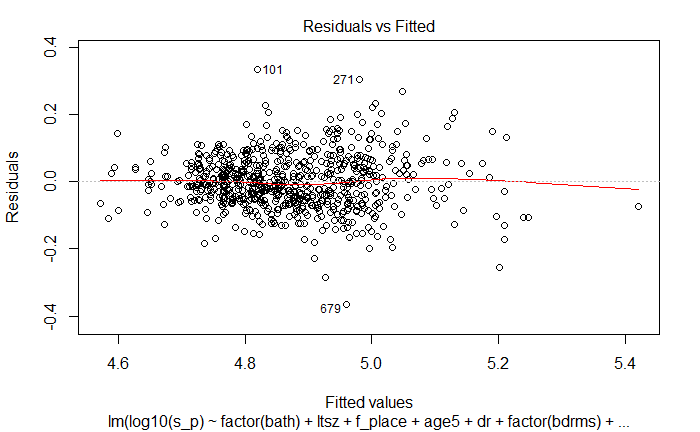

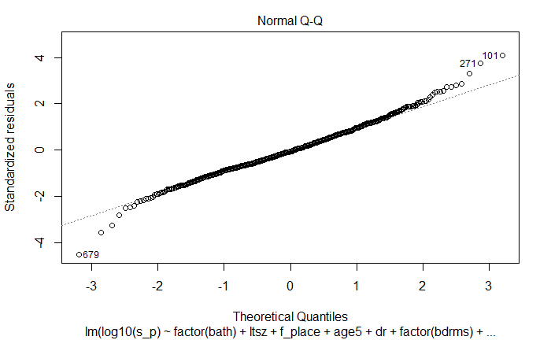

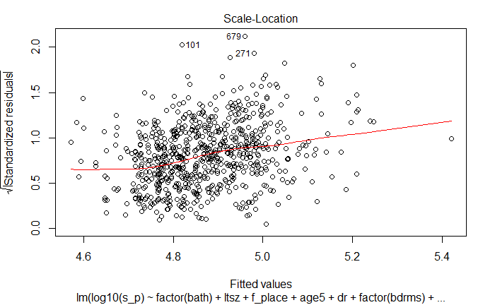

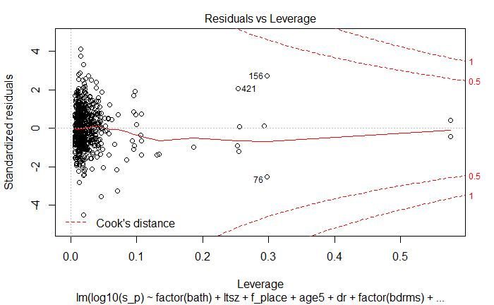

```r
plot(model2)
```

# Calculating Prediction Intervals

```r
mydatapredict<- mydata.test
mydatapredict$predvalue<-predict(model2,newdata = mydata.test)
mydatapredict$upper.int<- mydatapredict$predvalue + 0.07929*1.96
mydatapredict$lower.int<-mydatapredict$predvalue - 0.07929*1.96
mydatapredict$pv <- 10**mydatapredict$predvalue
mydatapredict$ul <- 10**mydatapredict$upper.int
mydatapredict$ll <- 10**mydatapredict$lower.int
mydatapredict$diffs <-mydatapredict$s_p - mydatapredict$pv
attach(mydatapredict)
incorrect <- mydatapredict[s_p <= ll | s_p >= ul, ]
#View(incorrect)
median(abs(mydatapredict$diffs))
```

```
[1] 8065.01
```

Analyzing Mean Squared Error

```r
MSE<-function(pred,actual){
  return(mean((pred-actual)^2))
}
pred.model1<-predict(model1,newdata = mydata.test)
pred.model2<-predict(model2,newdata = mydata.test)
pred.model3<-predict(everythingmodel,newdata = mydata.test)
data.frame(
  Model=c("Model1","Model2", "everything"),
  MSE=c(MSE(pred.model1,mydata.test$s_p),MSE(pred.model2,mydata.test$s_p),MSE(pred.model3,mydata.test$s_p)))
```

| Model | MSE |
| --- | --- |
| Model1 | 329104121 |
| Model2 | 7421960555 |
| everything | 368984591 |

## Visualizing the interval

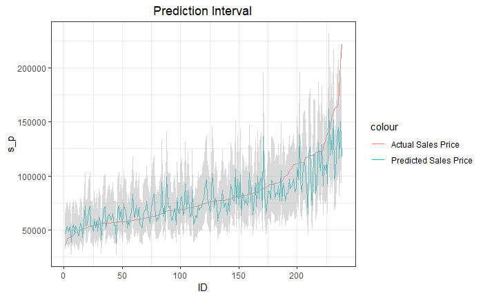

```r
mydatapredict <- mydatapredict[order(mydatapredict$s_p),]
mydatapredict$ID <- seq(1, nrow(mydatapredict), 1)
attach(mydatapredict)


  #take log
ggplot(data=mydatapredict,aes(x=ID,y=s_p))+
  geom_line(aes(y=s_p,color="Actual Sales Price"))+
  geom_line(aes(y=pv, color="Predicted Sales Price"))+
  theme_bw()+
  geom_ribbon(aes(ymin =ll, ymax = ul), fill="grey70",alpha=0.5)+
  ggtitle("Prediction Interval") +
  theme(plot.title = element_text(hjust = 0.5))
```

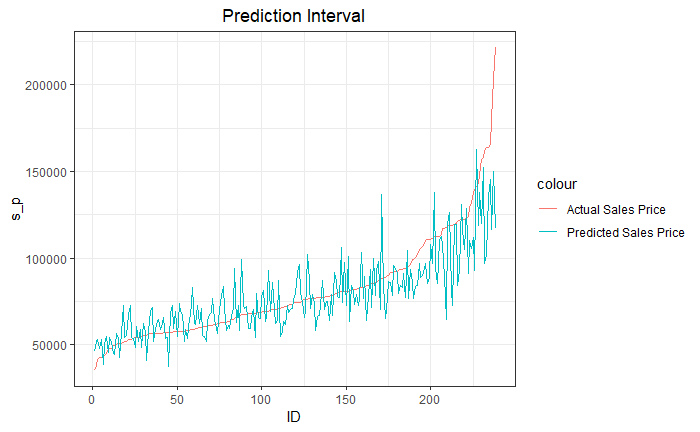

```r
ggplot(data=mydatapredict,aes(x=ID,y=s_p))+
  geom_line(aes(y=s_p,color="Actual Sales Price"))+
  geom_line(aes(y=pv, color="Predicted Sales Price"))+
  theme_bw()+
  ggtitle("Prediction Interval") +
  theme(plot.title = element_text(hjust = 0.5))
```

Because this is a log model, I see that as the sales price increases, so does the interval itself (shown in grey).

# Using the model to predict a new data point

Finally, I can take the information about the new house data and use the model to predict the correct interval.

```r
test <- data.frame(inv = 100, bath =2, hssz = 1200, bsemt = 0, a_c=1, f_place=0, garsz_a =1 , dw =1, dr=0, fr=0, age5=1, stl10=1, bdrms=4, ltsz = 0.25)
predict.lm(model2, newdata= test, interval = "prediction", level = .95)
```

```
       fit     lwr      upr
1 4.822592 4.66318 4.982003
```

```r
pointprediction <-10**4.822592
pointlower<-10**4.66318
pointupper <- 10**4.982003
print("Point Prediction:")
```

```
[1] "Point Prediction:"
```

```r
pointprediction
```

```
[1] 66464.85
```

```r
print("Lower Limit:")
```

```
[1] "Lower Limit:"
```

```r
pointlower
```

```
[1] 46044.74
```

```r
print("Upper Limit: ")
```

```
[1] "Upper Limit: "
```

```r
pointupper
```

```
[1] 95940.73
```

My best guess for the price of the house is $66,464.85. I am 95% confident that the model falls between $46,044.74 and $95,940.73.